# Домашнее задание №5

```python
%matplotlib inline
import matplotlib.pyplot as plt
from scipy import optimize
import subprocess
import numpy as np
import math
```

Генерация файлов для ORCA. Самое важное из того, что подается на вход это ТО, что менять (какой угол или связь), на что менять и с каким шагом.

```python
def file_generation(change, start, shag, way, N):

    inp = '''!HF RHF 6-31G
    * int 0 1
    C 0 0 0 0 0 0
    C 1 0 0 1.52986 0 0
    H 1 2 0 1.08439 111.200 0
    H 1 2 3 1.08439 111.200 120
    H 1 2 3 1.08439 111.200 -120
    H 2 1 3 1.08439 111.200 180
    H 2 1 6 1.08439 111.200 120
    H 2 1 6 1.08439 111.200 -120
    *
    '''

    #start = 1.32986
    for i in range(0,(N+1)):
        lenCC = start + shag*i
        inp_w = inp.replace(change,str(lenCC))
        with open(way+str(i)+'.inp', 'w') as outfile:
            outfile.write(inp_w)
```

Расчет энергии. Запускаем ORCA для каждого файла, затем в итоговой строке на выходе ищем число после фразы:'FINAL SINGLE POINT ENERGY'

```python
def energy_calculation(way1,N):

    ENERGY = []
    for i in range(0,N):
        way = way1+str(i)+'.inp'
        p = subprocess.Popen(way, shell=True, stdout=subprocess.PIPE, stderr=subprocess.PIPE)
        out=p.communicate()[0]
        out.splitlines()

        index = out.find('FINAL SINGLE POINT ENERGY')
        l = len('FINAL SINGLE POINT ENERGY  ')
        fl = 1
        while (fl==1):
            if out[l+index]==' ' : l = l+1
            else: fl = 2
        start = index+l
        while (fl == 2):
            if out[l+index]!='\n' : l = l+1
            else: fl = 3
        finish = index+l
        ENERGY.append(float(out[start:finish]))
    return ENERGY
```

Отрисовка. Точками выводим расчитанную энергию. Подбираем квадратичную функцию, которая наилучшим образом приближает энергию.

```python
def plot_energy(x_o, y_o, col):

    # function is  f(x)=k(b-x)^2 + a
    fitfunc = lambda p, x: p[0]*pow(p[1]-x,2) + p[2] # Target function
    errfunc = lambda p, x, y: fitfunc(p, x) - y # Error function

    p0 = [1,1, -79] # Initial guess for the parameters
    p1, success = optimize.leastsq(errfunc, p0[:], args=(x_o, y_o))
    print "Optimized params:", p1

    # Plot
    plt.plot(x_o, y_o, "ro", x_o,fitfunc(p1,x_o),"r-",c=col,alpha=0.5)
    plt.show()
```

Считаем изменение энергии, если длина связи между СС изменяется от 1.32986 до 1.70986. Видим, что минимум достигается в значении 1.52986.

```
Optimized params: [  0.66824638   1.55389271 -79.08233321]
```

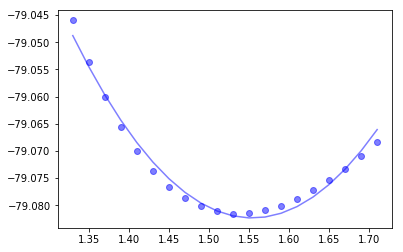

```python
file_generation(change = '1.52986', start = 1.32986, shag = 0.02, way = 'orca/CC/orca', N=20)
ENERGY = energy_calculation(way1 = '/Users/Ekaterina/Library/Orca401/orca /Users/Ekaterina/orca/CC/orca', N=20)
plot_energy(x_o = np.arange(1.32986,1.72986,0.02), y_o = np.array(ENERGY), col = 'blue')
```

Энергия аппроксимируется кривой вида: $ y(x) = 0.66(1.55-x)^2 -79.08$.

```
Optimized params: [  3.30818744e-04   1.12271980e+02  -7.90819115e+01]
```

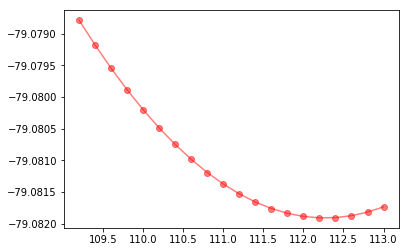

```python
file_generation(change = '111.200', start = 109.2, shag = 0.2, way = 'orca/HCC/orca', N = 20)
ENERGY2 = energy_calculation(way1 = '/Users/Ekaterina/Library/Orca401/orca /Users/Ekaterina/orca/HCC/orca', N=20)
plot_energy(x_o = np.arange(109.2,113.2,0.2), y_o = np.array(ENERGY2), col = 'red')
```

Энергия аппроксимируется кривой вида: $ y(x) = 3.30*10^{-4}(112.27-x)^2 -79.08$

Построим изменение энергии, если менять торсионный угол СС от -180 до 180 с шагом 12.

```
Optimized params: [ -1.68259119e-08   3.17840271e+01  -7.91950790e+01]
```

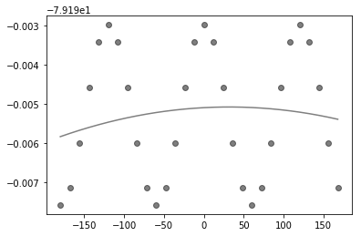

```python
file_generation(change = '180', start = -180, shag = 12, way = 'orca/torsCC/orca', N = 30)
ENERGY3 = energy_calculation(way1 = '/Users/Ekaterina/Library/Orca401/orca /Users/Ekaterina/orca/torsCC/orca', N=30)
plot_energy(x_o = np.arange(-180,180,12), y_o = np.array(ENERGY3), col = 'black')
```

Видим, что данная функция не фитится как квадратичная. Попробуем другой вид.

```
Optimized params: [ -4.08997993e-07   9.89258180e-01  -7.91952844e+01   2.29233518e-03
  -7.90110524e+01]
```

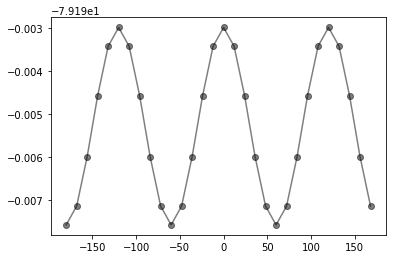

```python
x_o = np.arange(-180,180,12)
y_o = np.array(ENERGY3)
col = 'black'
fitfunc = lambda p, x: p[0]*np.sin(p[1]*x)+p[3]*np.cos(p[4]*x) + p[2] # Target function
errfunc = lambda p, x, y: fitfunc(p, x) - y # Error function

p0 = [1,1,1,1, -79] # Initial guess for the parameters
p1, success = optimize.leastsq(errfunc, p0[:], args=(x_o, y_o))
print "Optimized params:", p1

# Plot
plt.plot(x_o, y_o, "ro", x_o,fitfunc(p1,x_o),"r-",c=col,alpha=0.5)
plt.show()
```

На рассматриваемом промежутке минимумов функции будет три. Функция прекрасно аппроксимируется "подобием" ряда Фурье $y(x) = -4.08*10^{-7}sin(0.98x)+2.29*10^{-3}cos(-79.01x)-79.19$.

Увеличим шаг до 0.1 в длине связи и возьмем больше точек.

```
Optimized params: [  1.47803738   3.10806617 -80.8519376 ]
```

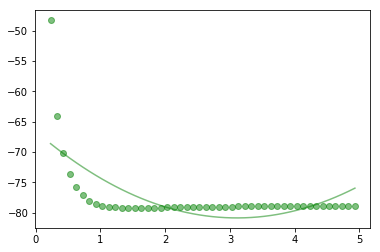

```python
file_generation(change = '1.52986', start = 0.22986, shag = 0.1, way = 'orca/CC01/orca', N=48)
ENERGY5 = energy_calculation(way1 = '/Users/Ekaterina/Library/Orca401/orca /Users/Ekaterina/orca/CC01/orca', N=48)
plot_energy(x_o = np.arange(0.22986,5.02986,0.1), y_o = np.array(ENERGY5), col = 'green')
```

Посмотрим на врезку, которую делали в начале ДЗ. Все похоже.

[figure not shown]

```python
x_o = np.arange(0.22986,5.02986,0.1)
y_o = np.array(ENERGY5)
plt.plot(x_o, y_o, "ro")
plt.xlim(1,2)
plt.ylim(-79.4,-78.7)
plt.show()
```

Зафитим функцию степенной.

```
Optimized params: [-79.09108449   2.34920309]
```

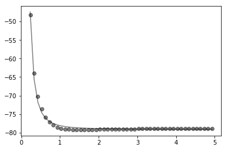

```python
x_o = np.arange(0.22986,5.02986,0.1)
y_o = np.array(ENERGY5)
col = 'black'
fitfunc = lambda p, x: pow(1/x,p[1])+p[0] # Target function
errfunc = lambda p, x, y: fitfunc(p, x) - y # Error function

p0 = [1, -79] # Initial guess for the parameters
p1, success = optimize.leastsq(errfunc, p0[:], args=(x_o, y_o))
print "Optimized params:", p1

# Plot
plt.plot(x_o, y_o, "ro", x_o,fitfunc(p1,x_o),"r-",c=col,alpha=0.5)
plt.show()
```

Итоговый вид: $y(x)= (x)^{-2.34}-79.09$